# 🧠 딥러닝 기반 뇌종양 분류

## 📌 프로젝트 정보

- **진행 기간**: 2023.08 ~ 2023.11
- **참여 형태**: 개인 프로젝트
- **프로젝트 개요**: MRI 뇌 영상 데이터를 기반으로 딥러닝 모델을 활용해 **뇌종양의 존재 여부 및 종류 분류**

## 🛠️ 사용 기술

### 📦 프레임워크 & 라이브러리

- TensorFlow / Keras
- Cv2
- Matplotlib
- Scikit-learn

### 💻 개발 환경

- Python
- PyCharm
- Jupyter Notebook

### 🧠 모델링 기법

- CNN
- Transfer Learning (ResNet50V2 기반)
- Fine-tuning

⚠️ 본 프로젝트는 머신러닝/딥러닝 기반으로 구현되었으며,  
모델 학습 시 초기 가중치, 데이터 셔플링, 실행 환경 등에 따라 결과가 소폭 달라질 수 있습니다.  
따라서 실행 시 출력되는 성능 수치나 시각화 결과는 본 문서에 기재된 내용과 일부 차이가 발생할 수 있습니다.

## 📂 데이터셋 정보

- **출처**: Kaggle의 [Brain Tumor MRI Dataset](https://www.kaggle.com/datasets/masoudnickparvar/brain-tumor-mri-dataset/data) 공개 데이터셋 사용
- **클래스 구성**:
  - `no_tumor`: 비종양 MRI 이미지
  - `glioma`: 신경교종 (가장 흔한 악성 뇌종양)
  - `meningioma`: 수막종 (두개 내 양성 종양)
  - `pituitary`: 뇌하수체 선종
- **데이터 규모**: 총 7,000장 이상의 MRI 이미지 (Train/Test 폴더 기준 분리)

| 구분 | meningioma | glioma | notumor | pituitary | 합계 | 전체 비율 |
| --- | --- | --- | --- | --- | --- | --- |
| **Train** | 1,339 | 1,321 | 1,595 | 1,457 | 5,712 | 81.3% |
| **Test** | 306 | 300 | 405 | 300 | 1,311 | 18.7% |
| **전체** | 1,645 | 1,621 | 2,000 | 1,757 | 7,023 | 100% |

- **데이터 분할 방식**:
  - 제공된 데이터셋은 `Training`, `Test` 폴더로 구성되어 있으며, `Test` 데이터를 **Validation 용도**로 사용함

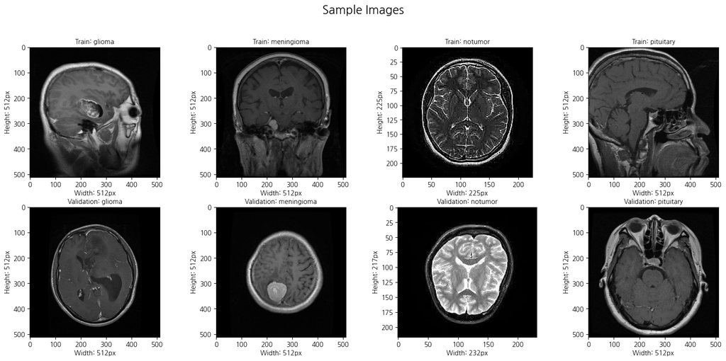

```python
import os
import random
import matplotlib.pyplot as plt
from PIL import Image

train_dir = 'dataset/Train'
val_dir = 'dataset/Validation'
classes = ['glioma', 'meningioma', 'notumor', 'pituitary']

fig, axes = plt.subplots(2, 4, figsize=(16, 8))
fig.suptitle("Sample Images", fontsize=18)

# Train
for i, cls in enumerate(classes):
    folder = os.path.join(train_dir, cls)
    img_file = random.choice(os.listdir(folder))
    img_path = os.path.join(folder, img_file)
    img = Image.open(img_path)
    width, height = img.size

    axes[0, i].imshow(img, cmap='gray')
    axes[0, i].set_title(f"Train: {cls}", fontsize=10)
    axes[0, i].set_xlabel(f"Width: {width}px")
    axes[0, i].set_ylabel(f"Height: {height}px")
    axes[0, i].axis('on')

# Validation
for i, cls in enumerate(classes):
    folder = os.path.join(val_dir, cls)
    img_file = random.choice(os.listdir(folder))
    img_path = os.path.join(folder, img_file)
    img = Image.open(img_path)
    width, height = img.size

    axes[1, i].imshow(img, cmap='gray')
    axes[1, i].set_title(f"Validation: {cls}", fontsize=10)
    axes[1, i].set_xlabel(f"Width: {width}px")
    axes[1, i].set_ylabel(f"Height: {height}px")
    axes[1, i].axis('on')

plt.tight_layout(rect=[0, 0.03, 1, 0.95])
plt.show()
```

```python
# 클래스별 이미지 수 계산
import pandas as pd

def count_exp(path, set_):
    dict_ = {}
    for expression in os.listdir(path):
        dir_ = os.path.join(path, expression)
        dict_[expression] = len(os.listdir(dir_))
    df = pd.DataFrame(dict_, index=[set_])
    return df

train_count = count_exp(train_dir, 'Train')
val_count = count_exp(val_dir, 'Validation')
print(train_count)
print(val_count)
```

```
       meningioma  glioma  notumor  pituitary
Train        1339    1321     1595       1457
            meningioma  glioma  notumor  pituitary
Validation         306     300      405        300
```

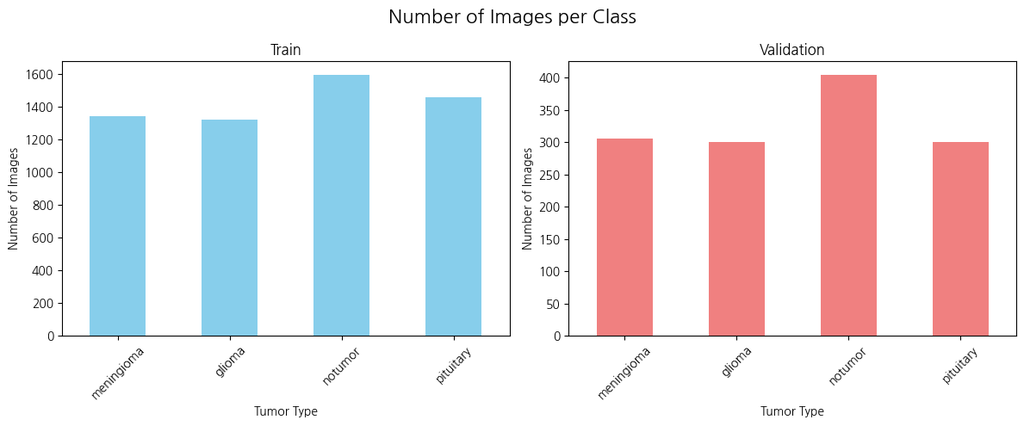

```python
fig, axes = plt.subplots(1, 2, figsize=(12, 5))
fig.suptitle("Number of Images per Class", fontsize=16)

# Train 바차트
train_count.T.plot(kind='bar', ax=axes[0], color='skyblue', legend=False)
axes[0].set_title("Train")
axes[0].set_xlabel("Tumor Type")
axes[0].set_ylabel("Number of Images")
axes[0].tick_params(axis='x', rotation=45)

# Validation 바차트
val_count.T.plot(kind='bar', ax=axes[1], color='lightcoral', legend=False)
axes[1].set_title("Validation")
axes[1].set_xlabel("Tumor Type")
axes[1].set_ylabel("Number of Images")
axes[1].tick_params(axis='x', rotation=45)

plt.tight_layout()
plt.show()
```

## 🧠 기본 CNN 모델 학습

Grayscale 이미지(512x512)를 입력으로 하는 간단한 CNN 모델을 구성하고,  
성능을 측정하여 baseline 정확도를 확인한다.

```python
# 기본적인 CNN모델 + 전처리(512 * 512, grayscale, 비율 고려 패딩)
import cv2
import numpy as np
from tensorflow.keras.utils import to_categorical
from tensorflow.keras.models import Sequential
from tensorflow.keras.layers import Conv2D, MaxPooling2D, Dense, Flatten
from tensorflow.keras.optimizers import Adam
from tensorflow.keras.callbacks import EarlyStopping

tumor_mapping = {
    'notumor': 0,
    'glioma': 1,
    'meningioma': 2,
    'pituitary': 3,
}

def process_images(folder_path):
    X, Y = [], []
    target_size = 512

    for tumor_type, label in tumor_mapping.items():
        tumor_path = os.path.join(folder_path, tumor_type)
        for filename in os.listdir(tumor_path):
            image_path = os.path.join(tumor_path, filename)
            image = cv2.imread(image_path, cv2.IMREAD_GRAYSCALE)
            if image is not None:
                h, w = image.shape[:2]
                scale_ratio = target_size / max(h, w)
                resized_image = cv2.resize(image, (int(w * scale_ratio), int(h * scale_ratio)))

                padded_image = np.zeros((target_size, target_size), dtype=np.uint8)
                y_offset = (target_size - resized_image.shape[0]) // 2
                x_offset = (target_size - resized_image.shape[1]) // 2

                padded_image[y_offset:y_offset + resized_image.shape[0],
                             x_offset:x_offset + resized_image.shape[1]] = resized_image

                X.append(padded_image)
                Y.append(label)

    X = np.array(X).reshape(-1, 512, 512, 1) / 255.0
    Y = to_categorical(np.array(Y), 4)
    return X, Y

X_train, y_train = process_images(train_dir)
X_val, y_val = process_images(val_dir)

model = Sequential([
    Conv2D(32, (3, 3), activation='relu', input_shape=(512, 512, 1)),
    MaxPooling2D((2, 2)),
    Conv2D(64, (3, 3), activation='relu'),
    MaxPooling2D((2, 2)),
    Conv2D(128, (3, 3), activation='relu'),
    MaxPooling2D((2, 2)),
    Flatten(),
    Dense(128, activation='relu'),
    Dense(4, activation='softmax')
])

model.compile(optimizer=Adam(), loss='categorical_crossentropy', metrics=['accuracy'])

early_stopping = EarlyStopping(monitor='val_loss', patience=5, restore_best_weights=True)

history = model.fit(
    X_train, y_train,
    validation_data=(X_val, y_val),
    epochs=20,
    batch_size=8,
    callbacks=[early_stopping],
    verbose=1
)

final_loss, final_accuracy = model.evaluate(X_val, y_val, verbose=0)
print(f"Val Accuracy: {final_accuracy:.4f}, Loss: {final_loss:.4f}")
```

[output not shown]

```
  5/714 ━━━━━━━━━━━━━━━━━━━━ 24s 34ms/step - accuracy: 0.2988 - loss: 4.5783
```

```
I0000 00:00:1744441663.403522   22355 device_compiler.h:188] Compiled cluster using XLA!  This line is logged at most once for the lifetime of the process.
```

```
713/714 ━━━━━━━━━━━━━━━━━━━━ 0s 33ms/step - accuracy: 0.6729 - loss: 0.9231
```

[output not shown]

```
714/714 ━━━━━━━━━━━━━━━━━━━━ 35s 42ms/step - accuracy: 0.6732 - loss: 0.9222 - val_accuracy: 0.8627 - val_loss: 0.3369
714/714 ━━━━━━━━━━━━━━━━━━━━ 25s 34ms/step - accuracy: 0.9122 - loss: 0.2380 - val_accuracy: 0.8658 - val_loss: 0.3582
714/714 ━━━━━━━━━━━━━━━━━━━━ 25s 34ms/step - accuracy: 0.9706 - loss: 0.0887 - val_accuracy: 0.9375 - val_loss: 0.1888
714/714 ━━━━━━━━━━━━━━━━━━━━ 24s 34ms/step - accuracy: 0.9843 - loss: 0.0471 - val_accuracy: 0.9466 - val_loss: 0.2511
714/714 ━━━━━━━━━━━━━━━━━━━━ 24s 34ms/step - accuracy: 0.9817 - loss: 0.0499 - val_accuracy: 0.9321 - val_loss: 0.2875
714/714 ━━━━━━━━━━━━━━━━━━━━ 24s 34ms/step - accuracy: 0.9840 - loss: 0.0497 - val_accuracy: 0.9512 - val_loss: 0.2647
714/714 ━━━━━━━━━━━━━━━━━━━━ 24s 34ms/step - accuracy: 0.9940 - loss: 0.0204 - val_accuracy: 0.9436 - val_loss: 0.3609
714/714 ━━━━━━━━━━━━━━━━━━━━ 24s 34ms/step - accuracy: 0.9877 - loss: 0.0385 - val_accuracy: 0.9382 - val_loss: 0.3249
```

```
2025-04-12 16:11:05.306220: W external/local_xla/xla/tsl/framework/cpu_allocator_impl.cc:83] Allocation of 1374683136 exceeds 10% of free system memory.
2025-04-12 16:11:07.742344: I external/local_xla/xla/stream_executor/cuda/subprocess_compilation.cc:346] ptxas warning : Registers are spilled to local memory in function 'gemm_fusion_dot_108', 4 bytes spill stores, 4 bytes spill loads
```

```
Val Accuracy: 0.9375, Loss: 0.1888
```

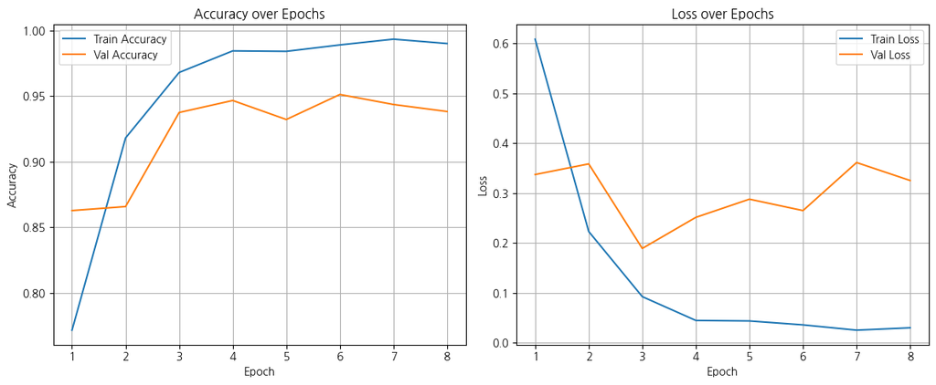

```python
acc = history.history['accuracy']
val_acc = history.history['val_accuracy']
loss = history.history['loss']
val_loss = history.history['val_loss']

epochs_range = range(1, len(acc) + 1)

plt.figure(figsize=(12, 5))

# 정확도 그래프
plt.subplot(1, 2, 1)
plt.plot(epochs_range, acc, label='Train Accuracy')
plt.plot(epochs_range, val_acc, label='Val Accuracy')
plt.title('Accuracy over Epochs')
plt.xlabel('Epoch')
plt.ylabel('Accuracy')
plt.legend()
plt.grid(True)

# 손실 그래프
plt.subplot(1, 2, 2)
plt.plot(epochs_range, loss, label='Train Loss')
plt.plot(epochs_range, val_loss, label='Val Loss')
plt.title('Loss over Epochs')
plt.xlabel('Epoch')
plt.ylabel('Loss')
plt.legend()
plt.grid(True)

plt.tight_layout()
plt.show()
```

```
41/41 ━━━━━━━━━━━━━━━━━━━━ 2s 30ms/step
```

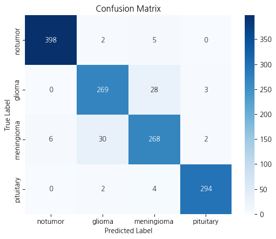

```python
from sklearn.metrics import confusion_matrix
import seaborn as sns
import matplotlib.pyplot as plt
import numpy as np

y_pred = model.predict(X_val)
y_pred_labels = np.argmax(y_pred, axis=1)
y_true_labels = np.argmax(y_val, axis=1)

class_names = list(tumor_mapping.keys())

cm = confusion_matrix(y_true_labels, y_pred_labels)

plt.figure(figsize=(6, 5))
sns.heatmap(cm, annot=True, fmt='d', cmap='Blues',
            xticklabels=class_names,
            yticklabels=class_names)

plt.xlabel('Predicted Label')
plt.ylabel('True Label')
plt.title('Confusion Matrix')
plt.tight_layout()
plt.show()
```

## 🔁 13개 전이학습 모델 비교 실험

DenseNet, MobileNet, EfficientNet, ResNet, VGG, Inception, Xception 계열 총 13개의 ImageNet 기반 사전학습 모델을 비교한다.  
모든 모델은 입력 크기를 (224, 224, 3)로 통일하여 공정한 비교를 수행하였고,  
학습률, batch size, early stopping 등의 설정도 동일하게 유지하였다.

```python
import tensorflow as tf
from tensorflow.keras.models import Model
from tensorflow.keras.layers import Input
from tensorflow.keras.applications import (
    DenseNet121, DenseNet201, MobileNetV2, MobileNetV3Large,
    EfficientNetB0, EfficientNetB1, InceptionV3, ResNet50,
    ResNet50V2, ResNet152V2, VGG16, VGG19, Xception
)
from tensorflow.keras import mixed_precision

# ✅ float16 혼합 정밀도 설정
mixed_precision.set_global_policy('mixed_float16')

# 이미지 전처리
def process_images(folder_path, target_size=224):
    X, Y = [], []
    for tumor_type, label in tumor_mapping.items():
        tumor_path = os.path.join(folder_path, tumor_type)
        for filename in os.listdir(tumor_path):
            image_path = os.path.join(tumor_path, filename)
            image = cv2.imread(image_path)
            if image is not None:
                h, w = image.shape[:2]
                scale_ratio = target_size / max(h, w)
                new_w, new_h = int(w * scale_ratio), int(h * scale_ratio)
                resized_image = cv2.resize(image, (new_w, new_h))

                # 중앙 정렬 패딩
                padded_image = np.zeros((target_size, target_size, 3), dtype=np.uint8)
                y_offset = (target_size - new_h) // 2
                x_offset = (target_size - new_w) // 2
                padded_image[y_offset:y_offset+new_h, x_offset:x_offset+new_w] = resized_image

                X.append(padded_image)
                Y.append(label)

    X = np.array(X, dtype=np.float16) / 255.0
    Y = to_categorical(np.array(Y), num_classes=4)
    return X, Y

X_train, y_train = process_images(train_dir)
X_val, y_val = process_images(val_dir)

model_dict = {
    'DenseNet121': DenseNet121,
    'DenseNet201': DenseNet201,
    'MobileNetV2': MobileNetV2,
    'MobileNetV3Large': MobileNetV3Large,
    'EfficientNetB0': EfficientNetB0,
    'EfficientNetB1': EfficientNetB1,
    'InceptionV3': InceptionV3,
    'ResNet50': ResNet50,
    'ResNet50V2': ResNet50V2,
    'ResNet152V2': ResNet152V2,
    'VGG16': VGG16,
    'VGG19': VGG19,
    'Xception': Xception,
}

def build_transfer_model(model_class, input_shape=(224, 224, 3)):
    base_model = model_class(include_top=False, weights='imagenet', input_shape=input_shape)
    base_model.trainable = False
    inputs = Input(shape=input_shape)
    x = base_model(inputs, training=False)
    x = Flatten()(x)
    x = Dense(128, activation='relu')(x)
    outputs = Dense(4, activation='softmax', dtype='float32')(x)
    return Model(inputs, outputs)

results = []
model_histories = []

for model_name, model_class in model_dict.items():
    print(f"\n🚀 Training model: {model_name}")

    input_shape = (224, 224, 3)
    batch_size = 8

    with tf.device('/GPU:0'):
        model = build_transfer_model(model_class, input_shape=input_shape)
        model.compile(optimizer=Adam(), loss='categorical_crossentropy', metrics=['accuracy'])

        early_stopping = EarlyStopping(monitor='val_loss', patience=3, restore_best_weights=True)

        history = model.fit(
            X_train, y_train,
            validation_data=(X_val, y_val),
            epochs=20,
            batch_size=batch_size,
            callbacks=[early_stopping],
            verbose=1
        )

    final_val_acc = history.history['val_accuracy'][-1]
    results.append((model_name, final_val_acc))
    model_histories.append((model_name, history))

    del model
    tf.keras.backend.clear_session()

results.sort(key=lambda x: x[1], reverse=True)
print("\n📊 모델별 Validation Accuracy 결과 (Top 정렬):")
for name, acc in results:
    print(f"{name}: {acc:.4f}")
```

```
🚀 Training model: DenseNet121
714/714 ━━━━━━━━━━━━━━━━━━━━ 0s 6ms/step - accuracy: 0.7676 - loss: 3.1382
```

[output not shown]

```
714/714 ━━━━━━━━━━━━━━━━━━━━ 33s 26ms/step - accuracy: 0.7677 - loss: 3.1353 - val_accuracy: 0.8635 - val_loss: 0.4155
714/714 ━━━━━━━━━━━━━━━━━━━━ 5s 7ms/step - accuracy: 0.9481 - loss: 0.1458 - val_accuracy: 0.9352 - val_loss: 0.2115
714/714 ━━━━━━━━━━━━━━━━━━━━ 5s 7ms/step - accuracy: 0.9687 - loss: 0.0938 - val_accuracy: 0.8673 - val_loss: 0.3940
714/714 ━━━━━━━━━━━━━━━━━━━━ 5s 7ms/step - accuracy: 0.9684 - loss: 0.0840 - val_accuracy: 0.9565 - val_loss: 0.1281
714/714 ━━━━━━━━━━━━━━━━━━━━ 5s 7ms/step - accuracy: 0.9859 - loss: 0.0428 - val_accuracy: 0.8650 - val_loss: 0.6143
714/714 ━━━━━━━━━━━━━━━━━━━━ 5s 7ms/step - accuracy: 0.9742 - loss: 0.0748 - val_accuracy: 0.9451 - val_loss: 0.1715
714/714 ━━━━━━━━━━━━━━━━━━━━ 5s 7ms/step - accuracy: 0.9806 - loss: 0.0626 - val_accuracy: 0.9649 - val_loss: 0.1233
714/714 ━━━━━━━━━━━━━━━━━━━━ 5s 7ms/step - accuracy: 0.9897 - loss: 0.0321 - val_accuracy: 0.9672 - val_loss: 0.1076
714/714 ━━━━━━━━━━━━━━━━━━━━ 5s 7ms/step - accuracy: 0.9907 - loss: 0.0270 - val_accuracy: 0.9413 - val_loss: 0.2305
714/714 ━━━━━━━━━━━━━━━━━━━━ 5s 7ms/step - accuracy: 0.9788 - loss: 0.0657 - val_accuracy: 0.9436 - val_loss: 0.1794
714/714 ━━━━━━━━━━━━━━━━━━━━ 5s 7ms/step - accuracy: 0.9891 - loss: 0.0319 - val_accuracy: 0.9611 - val_loss: 0.1463

🚀 Training model: DenseNet201
714/714 ━━━━━━━━━━━━━━━━━━━━ 56s 49ms/step - accuracy: 0.7738 - loss: 3.9131 - val_accuracy: 0.9237 - val_loss: 0.2188
714/714 ━━━━━━━━━━━━━━━━━━━━ 11s 16ms/step - accuracy: 0.9389 - loss: 0.1768 - val_accuracy: 0.8993 - val_loss: 0.2995
714/714 ━━━━━━━━━━━━━━━━━━━━ 12s 16ms/step - accuracy: 0.9607 - loss: 0.1176 - val_accuracy: 0.9428 - val_loss: 0.1634
714/714 ━━━━━━━━━━━━━━━━━━━━ 12s 16ms/step - accuracy: 0.9742 - loss: 0.0809 - val_accuracy: 0.9641 - val_loss: 0.1046
714/714 ━━━━━━━━━━━━━━━━━━━━ 11s 16ms/step - accuracy: 0.9882 - loss: 0.0332 - val_accuracy: 0.9657 - val_loss: 0.1086
714/714 ━━━━━━━━━━━━━━━━━━━━ 12s 16ms/step - accuracy: 0.9762 - loss: 0.0882 - val_accuracy: 0.9649 - val_loss: 0.0917
714/714 ━━━━━━━━━━━━━━━━━━━━ 11s 16ms/step - accuracy: 0.9794 - loss: 0.0573 - val_accuracy: 0.9580 - val_loss: 0.1088
714/714 ━━━━━━━━━━━━━━━━━━━━ 12s 16ms/step - accuracy: 0.9932 - loss: 0.0236 - val_accuracy: 0.9756 - val_loss: 0.0671
714/714 ━━━━━━━━━━━━━━━━━━━━ 11s 16ms/step - accuracy: 0.9858 - loss: 0.0406 - val_accuracy: 0.9397 - val_loss: 0.1970
714/714 ━━━━━━━━━━━━━━━━━━━━ 11s 16ms/step - accuracy: 0.9891 - loss: 0.0328 - val_accuracy: 0.9550 - val_loss: 0.1491
714/714 ━━━━━━━━━━━━━━━━━━━━ 11s 16ms/step - accuracy: 0.9873 - loss: 0.0336 - val_accuracy: 0.9603 - val_loss: 0.1822

🚀 Training model: MobileNetV2
714/714 ━━━━━━━━━━━━━━━━━━━━ 13s 13ms/step - accuracy: 0.8059 - loss: 2.8686 - val_accuracy: 0.9314 - val_loss: 0.2458
714/714 ━━━━━━━━━━━━━━━━━━━━ 4s 5ms/step - accuracy: 0.9519 - loss: 0.1689 - val_accuracy: 0.9565 - val_loss: 0.1221
714/714 ━━━━━━━━━━━━━━━━━━━━ 4s 5ms/step - accuracy: 0.9866 - loss: 0.0457 - val_accuracy: 0.9458 - val_loss: 0.1567
714/714 ━━━━━━━━━━━━━━━━━━━━ 4s 5ms/step - accuracy: 0.9750 - loss: 0.0733 - val_accuracy: 0.9596 - val_loss: 0.1452
714/714 ━━━━━━━━━━━━━━━━━━━━ 4s 5ms/step - accuracy: 0.9891 - loss: 0.0351 - val_accuracy: 0.9420 - val_loss: 0.2342

🚀 Training model: MobileNetV3Large
714/714 ━━━━━━━━━━━━━━━━━━━━ 15s 14ms/step - accuracy: 0.6465 - loss: 1.1770 - val_accuracy: 0.7384 - val_loss: 0.7115
714/714 ━━━━━━━━━━━━━━━━━━━━ 3s 5ms/step - accuracy: 0.7925 - loss: 0.5217 - val_accuracy: 0.7429 - val_loss: 0.6853
714/714 ━━━━━━━━━━━━━━━━━━━━ 3s 5ms/step - accuracy: 0.8143 - loss: 0.4891 - val_accuracy: 0.7567 - val_loss: 0.6434
714/714 ━━━━━━━━━━━━━━━━━━━━ 3s 5ms/step - accuracy: 0.8273 - loss: 0.4285 - val_accuracy: 0.8139 - val_loss: 0.4820
714/714 ━━━━━━━━━━━━━━━━━━━━ 3s 5ms/step - accuracy: 0.8387 - loss: 0.4262 - val_accuracy: 0.8093 - val_loss: 0.4853
714/714 ━━━━━━━━━━━━━━━━━━━━ 4s 5ms/step - accuracy: 0.8637 - loss: 0.3473 - val_accuracy: 0.8162 - val_loss: 0.4846
714/714 ━━━━━━━━━━━━━━━━━━━━ 3s 5ms/step - accuracy: 0.8626 - loss: 0.3475 - val_accuracy: 0.7994 - val_loss: 0.5177
```

[output cut: 86 more lines]

```

📊 모델별 Validation Accuracy 결과 (Top 정렬):
DenseNet121: 0.9611
DenseNet201: 0.9603
VGG19: 0.9565
ResNet152V2: 0.9535
MobileNetV2: 0.9420
VGG16: 0.9382
Xception: 0.9375
ResNet50V2: 0.9352
InceptionV3: 0.9062
MobileNetV3Large: 0.7994
ResNet50: 0.7292
EfficientNetB0: 0.3089
EfficientNetB1: 0.3089
```

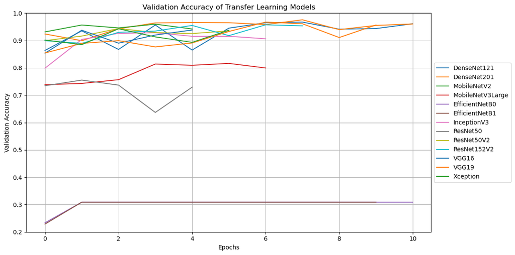

```python
plt.figure(figsize=(12, 6))

for model_name, hist in model_histories:
    val_acc = hist.history.get('val_accuracy')
    if val_acc:
        plt.plot(val_acc, label=model_name)

plt.title('Validation Accuracy of Transfer Learning Models')
plt.xlabel('Epochs')
plt.ylabel('Validation Accuracy')
plt.ylim(0.2, 1.0)
plt.grid(True)
plt.legend(loc='center left', bbox_to_anchor=(1, 0.5))
plt.tight_layout()
plt.show()
```

📌 참고: 전이학습 모델 비교 결과는 프로젝트 당시(CPU 환경, 특정 라이브러리 기준)에서의 실험을 기반으로 작성되었습니다.  
현재 환경(GPU, float16, 라이브러리 버전 변경 등)에서 동일한 실험을 반복한 결과 성능이 가장 우수한 모델의 순위가 일부 달라지는 결과가 확인되었습니다. 따라서 본 문서에서는 당시 기준으로 최적이었던 모델(ResNet50V2)을 중심으로 작성되었습니다.

```python
import os
import cv2
import numpy as np
import tensorflow as tf
from tensorflow.keras.utils import to_categorical
from tensorflow.keras.applications import ResNet50V2
from tensorflow.keras.models import Model
from tensorflow.keras.layers import GlobalAveragePooling2D, Dropout, Dense
from tensorflow.keras.optimizers import Adam
from tensorflow.keras.callbacks import EarlyStopping

# 클래스 매핑
tumor_mapping = {
    'notumor': 0,
    'glioma': 1,
    'meningioma': 2,
    'pituitary': 3,
}

# 전이학습 모델 구성 (ResNet50V2 + Custom Head)
base_model = ResNet50V2(weights='imagenet', include_top=False, input_shape=(224, 224, 3))
base_model.trainable = False

x = base_model.output
x = GlobalAveragePooling2D()(x)
x = Dropout(0.35)(x)
x = Dense(1024, activation='relu')(x)
predictions = Dense(4, activation='softmax')(x)

model = Model(inputs=base_model.input, outputs=predictions)

model.compile(optimizer=Adam(), loss='categorical_crossentropy', metrics=['accuracy'])

early_stopping = EarlyStopping(monitor='val_loss', patience=15, restore_best_weights=True)

history = model.fit(
    X_train, y_train,
    validation_data=(X_val, y_val),
    epochs=1000,
    batch_size=32,
    callbacks=[early_stopping],
    verbose=1
)

# 최적 가중치 기준 평가
final_loss, final_acc = model.evaluate(X_val, y_val, verbose=0)
print(f"✅ Restored Best Weights - Val Accuracy: {final_acc:.4f}, Loss: {final_loss:.4f}")

# 모델 저장
model.save('Transfer.h5')

# 예측 결과 저장 (추후 평가 및 시각화용)
y_pred_probs = model.predict(X_val)
y_pred = np.argmax(y_pred_probs, axis=1)
y_true = np.argmax(y_val, axis=1)
```

[output not shown]

```
178/179 ━━━━━━━━━━━━━━━━━━━━ 0s 21ms/step - accuracy: 0.7606 - loss: 0.7099
```

```
2025-04-09 18:10:16.291078: I external/local_xla/xla/stream_executor/cuda/subprocess_compilation.cc:346] ptxas warning : Registers are spilled to local memory in function 'gemm_fusion_dot_5219', 12 bytes spill stores, 12 bytes spill loads

2025-04-09 18:10:16.790800: I external/local_xla/xla/stream_executor/cuda/subprocess_compilation.cc:346] ptxas warning : Registers are spilled to local memory in function 'gemm_fusion_dot_5219', 616 bytes spill stores, 616 bytes spill loads
```

```
179/179 ━━━━━━━━━━━━━━━━━━━━ 0s 40ms/step - accuracy: 0.7610 - loss: 0.7088
```

[output not shown]

```
179/179 ━━━━━━━━━━━━━━━━━━━━ 23s 91ms/step - accuracy: 0.7613 - loss: 0.7077 - val_accuracy: 0.8825 - val_loss: 0.3122
179/179 ━━━━━━━━━━━━━━━━━━━━ 5s 27ms/step - accuracy: 0.8941 - loss: 0.3024 - val_accuracy: 0.9138 - val_loss: 0.2248
179/179 ━━━━━━━━━━━━━━━━━━━━ 5s 26ms/step - accuracy: 0.9047 - loss: 0.2407 - val_accuracy: 0.9100 - val_loss: 0.2522
179/179 ━━━━━━━━━━━━━━━━━━━━ 5s 27ms/step - accuracy: 0.9163 - loss: 0.2233 - val_accuracy: 0.9222 - val_loss: 0.2121
179/179 ━━━━━━━━━━━━━━━━━━━━ 5s 27ms/step - accuracy: 0.9358 - loss: 0.1747 - val_accuracy: 0.9298 - val_loss: 0.1856
179/179 ━━━━━━━━━━━━━━━━━━━━ 5s 27ms/step - accuracy: 0.9312 - loss: 0.1754 - val_accuracy: 0.9405 - val_loss: 0.1519
179/179 ━━━━━━━━━━━━━━━━━━━━ 5s 27ms/step - accuracy: 0.9402 - loss: 0.1513 - val_accuracy: 0.9222 - val_loss: 0.2032
179/179 ━━━━━━━━━━━━━━━━━━━━ 5s 27ms/step - accuracy: 0.9561 - loss: 0.1168 - val_accuracy: 0.9260 - val_loss: 0.1813
179/179 ━━━━━━━━━━━━━━━━━━━━ 5s 27ms/step - accuracy: 0.9569 - loss: 0.1233 - val_accuracy: 0.9428 - val_loss: 0.1510
179/179 ━━━━━━━━━━━━━━━━━━━━ 5s 27ms/step - accuracy: 0.9666 - loss: 0.0918 - val_accuracy: 0.9535 - val_loss: 0.1139
179/179 ━━━━━━━━━━━━━━━━━━━━ 5s 26ms/step - accuracy: 0.9688 - loss: 0.0835 - val_accuracy: 0.9519 - val_loss: 0.1237
179/179 ━━━━━━━━━━━━━━━━━━━━ 5s 27ms/step - accuracy: 0.9709 - loss: 0.0724 - val_accuracy: 0.9558 - val_loss: 0.1135
179/179 ━━━━━━━━━━━━━━━━━━━━ 5s 27ms/step - accuracy: 0.9807 - loss: 0.0583 - val_accuracy: 0.9458 - val_loss: 0.1571
179/179 ━━━━━━━━━━━━━━━━━━━━ 5s 27ms/step - accuracy: 0.9735 - loss: 0.0755 - val_accuracy: 0.9565 - val_loss: 0.1014
179/179 ━━━━━━━━━━━━━━━━━━━━ 5s 26ms/step - accuracy: 0.9707 - loss: 0.0722 - val_accuracy: 0.9558 - val_loss: 0.1184
179/179 ━━━━━━━━━━━━━━━━━━━━ 5s 26ms/step - accuracy: 0.9794 - loss: 0.0549 - val_accuracy: 0.9329 - val_loss: 0.2362
179/179 ━━━━━━━━━━━━━━━━━━━━ 5s 26ms/step - accuracy: 0.9788 - loss: 0.0644 - val_accuracy: 0.9626 - val_loss: 0.1028
179/179 ━━━━━━━━━━━━━━━━━━━━ 5s 26ms/step - accuracy: 0.9792 - loss: 0.0590 - val_accuracy: 0.9626 - val_loss: 0.1018
179/179 ━━━━━━━━━━━━━━━━━━━━ 5s 26ms/step - accuracy: 0.9828 - loss: 0.0526 - val_accuracy: 0.9542 - val_loss: 0.1567
179/179 ━━━━━━━━━━━━━━━━━━━━ 5s 26ms/step - accuracy: 0.9730 - loss: 0.0777 - val_accuracy: 0.9634 - val_loss: 0.1095
179/179 ━━━━━━━━━━━━━━━━━━━━ 5s 26ms/step - accuracy: 0.9809 - loss: 0.0470 - val_accuracy: 0.9573 - val_loss: 0.1358
179/179 ━━━━━━━━━━━━━━━━━━━━ 5s 26ms/step - accuracy: 0.9812 - loss: 0.0487 - val_accuracy: 0.9626 - val_loss: 0.1055
179/179 ━━━━━━━━━━━━━━━━━━━━ 5s 26ms/step - accuracy: 0.9842 - loss: 0.0413 - val_accuracy: 0.9619 - val_loss: 0.1382
179/179 ━━━━━━━━━━━━━━━━━━━━ 5s 26ms/step - accuracy: 0.9878 - loss: 0.0348 - val_accuracy: 0.9466 - val_loss: 0.2341
179/179 ━━━━━━━━━━━━━━━━━━━━ 5s 26ms/step - accuracy: 0.9839 - loss: 0.0409 - val_accuracy: 0.9596 - val_loss: 0.1410
179/179 ━━━━━━━━━━━━━━━━━━━━ 5s 27ms/step - accuracy: 0.9876 - loss: 0.0409 - val_accuracy: 0.9695 - val_loss: 0.1090
179/179 ━━━━━━━━━━━━━━━━━━━━ 5s 26ms/step - accuracy: 0.9817 - loss: 0.0454 - val_accuracy: 0.9619 - val_loss: 0.1442
179/179 ━━━━━━━━━━━━━━━━━━━━ 5s 27ms/step - accuracy: 0.9880 - loss: 0.0360 - val_accuracy: 0.9703 - val_loss: 0.0873
179/179 ━━━━━━━━━━━━━━━━━━━━ 5s 26ms/step - accuracy: 0.9868 - loss: 0.0318 - val_accuracy: 0.9519 - val_loss: 0.1782
179/179 ━━━━━━━━━━━━━━━━━━━━ 5s 26ms/step - accuracy: 0.9852 - loss: 0.0467 - val_accuracy: 0.9550 - val_loss: 0.1533
179/179 ━━━━━━━━━━━━━━━━━━━━ 5s 27ms/step - accuracy: 0.9841 - loss: 0.0428 - val_accuracy: 0.9603 - val_loss: 0.1569
179/179 ━━━━━━━━━━━━━━━━━━━━ 5s 26ms/step - accuracy: 0.9911 - loss: 0.0279 - val_accuracy: 0.9657 - val_loss: 0.1170
179/179 ━━━━━━━━━━━━━━━━━━━━ 5s 27ms/step - accuracy: 0.9858 - loss: 0.0331 - val_accuracy: 0.9649 - val_loss: 0.1245
179/179 ━━━━━━━━━━━━━━━━━━━━ 5s 27ms/step - accuracy: 0.9892 - loss: 0.0289 - val_accuracy: 0.9680 - val_loss: 0.1069
179/179 ━━━━━━━━━━━━━━━━━━━━ 5s 26ms/step - accuracy: 0.9912 - loss: 0.0287 - val_accuracy: 0.9512 - val_loss: 0.2308
179/179 ━━━━━━━━━━━━━━━━━━━━ 5s 26ms/step - accuracy: 0.9921 - loss: 0.0237 - val_accuracy: 0.9664 - val_loss: 0.1054
```

[output cut: 18 more lines]

```
WARNING:absl:You are saving your model as an HDF5 file via `model.save()` or `keras.saving.save_model(model)`. This file format is considered legacy. We recommend using instead the native Keras format, e.g. `model.save('my_model.keras')` or `keras.saving.save_model(model, 'my_model.keras')`.
```

```
✅ Restored Best Weights - Val Accuracy: 0.9748, Loss: 0.0797
41/41 ━━━━━━━━━━━━━━━━━━━━ 4s 64ms/step
```

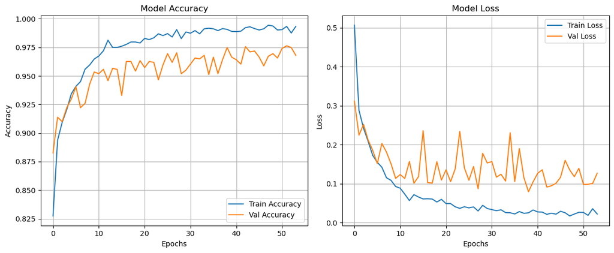

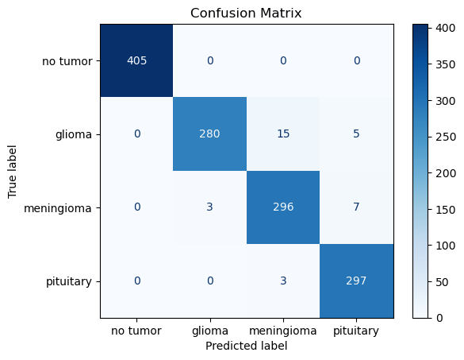

```python
from sklearn.metrics import ConfusionMatrixDisplay

# --------- 1. 정확도 & 손실 그래프 ---------
plt.figure(figsize=(12, 5))

# 정확도
plt.subplot(1, 2, 1)
plt.plot(history.history['accuracy'], label='Train Accuracy')
plt.plot(history.history['val_accuracy'], label='Val Accuracy')
plt.title('Model Accuracy')
plt.xlabel('Epochs')
plt.ylabel('Accuracy')
plt.legend()
plt.grid(True)

# 손실
plt.subplot(1, 2, 2)
plt.plot(history.history['loss'], label='Train Loss')
plt.plot(history.history['val_loss'], label='Val Loss')
plt.title('Model Loss')
plt.xlabel('Epochs')
plt.ylabel('Loss')
plt.legend()
plt.grid(True)

plt.tight_layout()
plt.show()

# --------- 2. 혼동행렬 ---------
cm = confusion_matrix(y_true, y_pred)
disp = ConfusionMatrixDisplay(confusion_matrix=cm, display_labels=['no tumor', 'glioma', 'meningioma', 'pituitary'])

plt.figure(figsize=(6, 6))
disp.plot(cmap=plt.cm.Blues, values_format='d')
plt.title('Confusion Matrix')
plt.grid(False)
plt.show()
```

```python
from sklearn.metrics import classification_report

target_names = ['no tumor', 'glioma', 'meningioma', 'pituitary']
report = classification_report(y_true, y_pred, target_names=target_names)

print("📋 Classification Report:\n")
print(report)
```

```
📋 Classification Report:

              precision    recall  f1-score   support

    no tumor       1.00      1.00      1.00       405
      glioma       0.99      0.93      0.96       300
  meningioma       0.94      0.97      0.95       306
   pituitary       0.96      0.99      0.98       300

    accuracy                           0.97      1311
   macro avg       0.97      0.97      0.97      1311
weighted avg       0.98      0.97      0.97      1311
```

## 🧪 ResNet50V2 성능 분석

전이학습 결과 정확도는 97%로 상승하였고, 종양을 정상으로 분류하는 오류는 발생하지 않았다.  
하지만 일부 클래스의 Precision, Recall, F1-score가 상대적으로 낮아 여전히 성능 개선 여지가 있다.

## 🧬 Conv5 블록 동결 해제 후 미세조정

ResNet50V2의 마지막 Conv5 블록만 동결을 해제하여 미세조정을 수행하였다.  
학습률을 낮게 설정하여 모델이 기존 Feature를 유지하면서 뇌종양 데이터에 더욱 특화되도록 조정하였다.

```python
from tensorflow.keras.models import load_model

# 모델 불러오기
model = load_model('Transfer.h5')

# conv5로 시작하는 레이어만 학습 가능하게 설정
for layer in model.layers:
    if layer.name.startswith('conv5'):
        layer.trainable = True
    else:
        layer.trainable = False

# 컴파일
model.compile(optimizer=Adam(learning_rate=0.0001),
              loss='categorical_crossentropy',
              metrics=['accuracy'])

# 미세조정 학습
history_fine_tune = model.fit(
    X_train, y_train,
    validation_data=(X_val, y_val),
    epochs=1000,
    batch_size=32,
    callbacks=[early_stopping],
    verbose=1
)

final_loss, final_acc = model.evaluate(X_val, y_val, verbose=0)
print(f"✅ Restored Best Weights - Val Accuracy: {final_acc:.4f}, Loss: {final_loss:.4f}")

model.save('Fine.h5')
```

[output not shown]

[output not shown]

```
  3/179 ━━━━━━━━━━━━━━━━━━━━ 6s 38ms/step - accuracy: 0.8316 - loss: 0.7439
```

```
I0000 00:00:1744442708.592876   27313 device_compiler.h:188] Compiled cluster using XLA!  This line is logged at most once for the lifetime of the process.
```

```
177/179 ━━━━━━━━━━━━━━━━━━━━ 0s 36ms/step - accuracy: 0.9059 - loss: 0.3511
```

```
2025-04-12 16:25:16.453921: I external/local_xla/xla/stream_executor/cuda/subprocess_compilation.cc:346] ptxas warning : Registers are spilled to local memory in function 'gemm_fusion_dot_6308', 12 bytes spill stores, 12 bytes spill loads

2025-04-12 16:25:16.775672: I external/local_xla/xla/stream_executor/cuda/subprocess_compilation.cc:346] ptxas warning : Registers are spilled to local memory in function 'gemm_fusion_dot_6308', 616 bytes spill stores, 616 bytes spill loads
```

```
179/179 ━━━━━━━━━━━━━━━━━━━━ 0s 68ms/step - accuracy: 0.9062 - loss: 0.3497
```

[output not shown]

```
179/179 ━━━━━━━━━━━━━━━━━━━━ 34s 122ms/step - accuracy: 0.9063 - loss: 0.3491 - val_accuracy: 0.9558 - val_loss: 0.1528
179/179 ━━━━━━━━━━━━━━━━━━━━ 7s 41ms/step - accuracy: 0.9789 - loss: 0.0616 - val_accuracy: 0.9771 - val_loss: 0.0811
179/179 ━━━━━━━━━━━━━━━━━━━━ 7s 41ms/step - accuracy: 0.9915 - loss: 0.0315 - val_accuracy: 0.9725 - val_loss: 0.0711
179/179 ━━━━━━━━━━━━━━━━━━━━ 7s 41ms/step - accuracy: 0.9883 - loss: 0.0408 - val_accuracy: 0.9809 - val_loss: 0.0767
179/179 ━━━━━━━━━━━━━━━━━━━━ 7s 41ms/step - accuracy: 0.9826 - loss: 0.0561 - val_accuracy: 0.9748 - val_loss: 0.0889
179/179 ━━━━━━━━━━━━━━━━━━━━ 7s 41ms/step - accuracy: 0.9919 - loss: 0.0188 - val_accuracy: 0.9748 - val_loss: 0.1117
179/179 ━━━━━━━━━━━━━━━━━━━━ 7s 41ms/step - accuracy: 0.9903 - loss: 0.0287 - val_accuracy: 0.9802 - val_loss: 0.0632
179/179 ━━━━━━━━━━━━━━━━━━━━ 7s 41ms/step - accuracy: 0.9877 - loss: 0.0562 - val_accuracy: 0.9718 - val_loss: 0.0767
179/179 ━━━━━━━━━━━━━━━━━━━━ 7s 40ms/step - accuracy: 0.9874 - loss: 0.0371 - val_accuracy: 0.9710 - val_loss: 0.0806
179/179 ━━━━━━━━━━━━━━━━━━━━ 7s 40ms/step - accuracy: 0.9905 - loss: 0.0250 - val_accuracy: 0.9817 - val_loss: 0.0533
179/179 ━━━━━━━━━━━━━━━━━━━━ 7s 40ms/step - accuracy: 0.9988 - loss: 0.0047 - val_accuracy: 0.9817 - val_loss: 0.0637
179/179 ━━━━━━━━━━━━━━━━━━━━ 7s 40ms/step - accuracy: 0.9966 - loss: 0.0135 - val_accuracy: 0.9809 - val_loss: 0.0874
179/179 ━━━━━━━━━━━━━━━━━━━━ 7s 40ms/step - accuracy: 0.9965 - loss: 0.0089 - val_accuracy: 0.9802 - val_loss: 0.0766
179/179 ━━━━━━━━━━━━━━━━━━━━ 7s 40ms/step - accuracy: 0.9918 - loss: 0.0426 - val_accuracy: 0.9786 - val_loss: 0.0565
179/179 ━━━━━━━━━━━━━━━━━━━━ 7s 40ms/step - accuracy: 0.9875 - loss: 0.0500 - val_accuracy: 0.9764 - val_loss: 0.0807
179/179 ━━━━━━━━━━━━━━━━━━━━ 7s 41ms/step - accuracy: 0.9904 - loss: 0.0217 - val_accuracy: 0.9863 - val_loss: 0.0454
179/179 ━━━━━━━━━━━━━━━━━━━━ 7s 41ms/step - accuracy: 0.9948 - loss: 0.0133 - val_accuracy: 0.9916 - val_loss: 0.0279
179/179 ━━━━━━━━━━━━━━━━━━━━ 7s 40ms/step - accuracy: 0.9991 - loss: 0.0018 - val_accuracy: 0.9901 - val_loss: 0.0456
179/179 ━━━━━━━━━━━━━━━━━━━━ 7s 40ms/step - accuracy: 1.0000 - loss: 5.6847e-04 - val_accuracy: 0.9893 - val_loss: 0.0360
179/179 ━━━━━━━━━━━━━━━━━━━━ 7s 41ms/step - accuracy: 0.9964 - loss: 0.0130 - val_accuracy: 0.9870 - val_loss: 0.0430
179/179 ━━━━━━━━━━━━━━━━━━━━ 7s 41ms/step - accuracy: 0.9999 - loss: 5.1525e-04 - val_accuracy: 0.9916 - val_loss: 0.0414
179/179 ━━━━━━━━━━━━━━━━━━━━ 7s 41ms/step - accuracy: 1.0000 - loss: 1.3676e-04 - val_accuracy: 0.9916 - val_loss: 0.0422
179/179 ━━━━━━━━━━━━━━━━━━━━ 7s 41ms/step - accuracy: 0.9988 - loss: 0.0069 - val_accuracy: 0.9176 - val_loss: 0.7675
179/179 ━━━━━━━━━━━━━━━━━━━━ 7s 40ms/step - accuracy: 0.9776 - loss: 0.1059 - val_accuracy: 0.8871 - val_loss: 0.4892
179/179 ━━━━━━━━━━━━━━━━━━━━ 7s 41ms/step - accuracy: 0.9785 - loss: 0.0791 - val_accuracy: 0.9832 - val_loss: 0.0596
179/179 ━━━━━━━━━━━━━━━━━━━━ 7s 40ms/step - accuracy: 0.9960 - loss: 0.0172 - val_accuracy: 0.9886 - val_loss: 0.0348
179/179 ━━━━━━━━━━━━━━━━━━━━ 7s 40ms/step - accuracy: 0.9981 - loss: 0.0060 - val_accuracy: 0.9771 - val_loss: 0.0887
179/179 ━━━━━━━━━━━━━━━━━━━━ 7s 41ms/step - accuracy: 0.9945 - loss: 0.0236 - val_accuracy: 0.9863 - val_loss: 0.0649
179/179 ━━━━━━━━━━━━━━━━━━━━ 7s 40ms/step - accuracy: 0.9958 - loss: 0.0278 - val_accuracy: 0.9878 - val_loss: 0.0397
179/179 ━━━━━━━━━━━━━━━━━━━━ 7s 40ms/step - accuracy: 0.9966 - loss: 0.0110 - val_accuracy: 0.9855 - val_loss: 0.0510
179/179 ━━━━━━━━━━━━━━━━━━━━ 7s 41ms/step - accuracy: 0.9955 - loss: 0.0154 - val_accuracy: 0.9863 - val_loss: 0.0612
179/179 ━━━━━━━━━━━━━━━━━━━━ 7s 40ms/step - accuracy: 0.9991 - loss: 0.0060 - val_accuracy: 0.9878 - val_loss: 0.0389
```

```
WARNING:absl:You are saving your model as an HDF5 file via `model.save()` or `keras.saving.save_model(model)`. This file format is considered legacy. We recommend using instead the native Keras format, e.g. `model.save('my_model.keras')` or `keras.saving.save_model(model, 'my_model.keras')`.
```

```
✅ Restored Best Weights - Val Accuracy: 0.9916, Loss: 0.0279
```

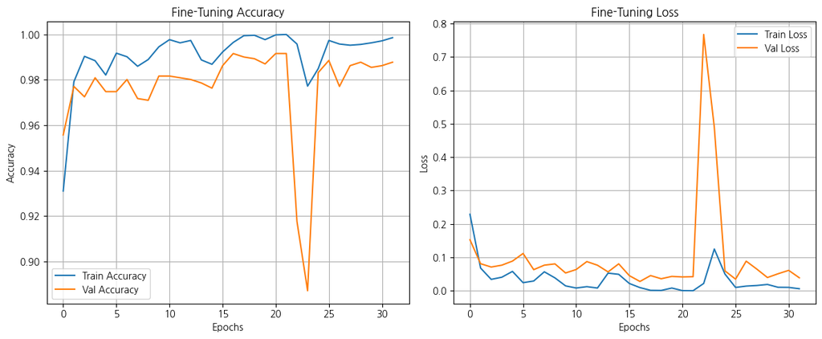

```python
plt.figure(figsize=(12, 5))

# 정확도
plt.subplot(1, 2, 1)
plt.plot(history_fine_tune.history['accuracy'], label='Train Accuracy')
plt.plot(history_fine_tune.history['val_accuracy'], label='Val Accuracy')
plt.title('Fine-Tuning Accuracy')
plt.xlabel('Epochs')
plt.ylabel('Accuracy')
plt.legend()
plt.grid(True)

# 손실
plt.subplot(1, 2, 2)
plt.plot(history_fine_tune.history['loss'], label='Train Loss')
plt.plot(history_fine_tune.history['val_loss'], label='Val Loss')
plt.title('Fine-Tuning Loss')
plt.xlabel('Epochs')
plt.ylabel('Loss')
plt.legend()
plt.grid(True)

plt.tight_layout()
plt.show()
```

```
41/41 ━━━━━━━━━━━━━━━━━━━━ 5s 68ms/step
```

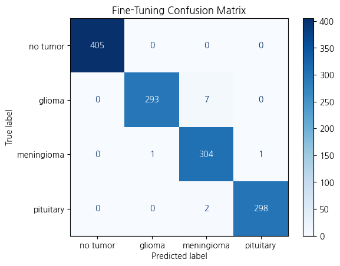

```python
from sklearn.metrics import confusion_matrix, ConfusionMatrixDisplay

# 새로운 예측값 생성
y_pred_probs_finetune = model.predict(X_val)
y_pred_finetune = np.argmax(y_pred_probs_finetune, axis=1)
y_true = np.argmax(y_val, axis=1)

# 혼동행렬
cm_finetune = confusion_matrix(y_true, y_pred_finetune)
disp_finetune = ConfusionMatrixDisplay(confusion_matrix=cm_finetune, display_labels=['no tumor', 'glioma', 'meningioma', 'pituitary'])

plt.figure(figsize=(6, 6))
disp_finetune.plot(cmap=plt.cm.Blues, values_format='d')
plt.title('Fine-Tuning Confusion Matrix')
plt.grid(False)
plt.show()
```

```python
from sklearn.metrics import classification_report

target_names = ['no tumor', 'glioma', 'meningioma', 'pituitary']
report_finetune = classification_report(y_true, y_pred_finetune, target_names=target_names)

print("📋 Classification Report (Fine-Tuned Model):\n")
print(report_finetune)
```

```
📋 Classification Report (Fine-Tuned Model):

              precision    recall  f1-score   support

    no tumor       1.00      1.00      1.00       405
      glioma       1.00      0.98      0.99       300
  meningioma       0.97      0.99      0.98       306
   pituitary       1.00      0.99      0.99       300

    accuracy                           0.99      1311
   macro avg       0.99      0.99      0.99      1311
weighted avg       0.99      0.99      0.99      1311
```

## Fine-Tuning 결과 요약

- 전이학습 기반 모델(ResNet50V2)에 Fine-Tuning을 적용하여 추가 학습을 진행함
- Validation 데이터 기준으로 다음과 같은 성능을 달성함:
  - Accuracy: **0.99**
  - 모든 클래스에서 Precision, Recall, F1-score: **0.97 ~ 1.00**
  - Confusion Matrix 상에서 종양을 정상으로 잘못 분류한 경우 없음

## ✅ 최종 결론

본 프로젝트에서는 MRI 기반 뇌종양 영상 데이터를 활용하여  
종양의 유무와 종류를 분류하는 딥러닝 모델을 개발하였다.

실험 과정 전반을 통해 단순한 정확도 향상뿐만 아니라,  
실제 오분류(특히 종양을 정상으로 판단하는 경우)를 줄이는 방향으로 모델을 개선함.